# Principal Component Analysis with Cancer Data

# Q6 Create a covariance matrix for identifying Principal components

```python
# PCA
# Step 1 - Create covariance matrix
```

```python
from sklearn.model_selection import train_test_split
X = datab_df.drop(['Class'],axis=1)
Y = datab_df[['Class']]
test_size = 0.30
seed = 7
X_train, X_test, y_train, y_test = train_test_split(X, Y, test_size=test_size, random_state=seed)
```

```python
from sklearn.preprocessing import StandardScaler

sc = StandardScaler()


X_train_std = sc.fit_transform(X_train)  # scale training and test data independently to prevent data leaks
X_test_std = sc.fit_transform(X_test)
```

```python
cov_matrix = np.cov(X_train_std.T)

print('Covariance Matrix \n%s', cov_matrix)
```

```
Covariance Matrix
%s [[1.00222222 0.6541539  0.66808719 0.49313848 0.57717287 0.56833186
  0.57350825 0.57717287 0.        ]
 [0.6541539  1.00222222 0.89567049 0.71650189 0.76556028 0.66897434
  0.76651956 0.76556028 0.        ]
 [0.66808719 0.89567049 1.00222222 0.68862392 0.75038436 0.68737318
  0.73811726 0.75038436 0.        ]
 [0.49313848 0.71650189 0.68862392 1.00222222 0.62117138 0.67620791
  0.62966393 0.62117138 0.        ]
 [0.57717287 0.76556028 0.75038436 0.62117138 1.00222222 0.62058355
  0.6803767  1.00222222 0.        ]
 [0.56833186 0.66897434 0.68737318 0.67620791 0.62058355 1.00222222
  0.66328304 0.62058355 0.        ]
 [0.57350825 0.76651956 0.73811726 0.62966393 0.6803767  0.66328304
  1.00222222 0.6803767  0.        ]
 [0.57717287 0.76556028 0.75038436 0.62117138 1.00222222 0.62058355
  0.6803767  1.00222222 0.        ]
 [0.         0.         0.         0.         0.         0.
  0.         0.         0.        ]]
```

# Q7 Identify eigen values and eigen vector

```python
# Step 2- Get eigen values and eigen vector
```

```python
eig_vals, eig_vecs = np.linalg.eig(cov_matrix)
print('Eigen Vectors \n%s', eig_vecs)
print('\n Eigen Values \n%s', eig_vals)
```

```
Eigen Vectors
%s [[-3.08403874e-01 -2.63923113e-01 -8.19899077e-01 -2.75056773e-01
  -2.52035562e-01 -1.53995504e-01 -1.02164803e-02  8.88146356e-17
   0.00000000e+00]
 [-3.81706995e-01 -4.66832865e-02 -2.69906040e-02  3.31476432e-01
   3.92090550e-01 -1.96461563e-01 -7.41068943e-01  8.13379984e-16
   0.00000000e+00]
 [-3.78211645e-01 -7.74576123e-02 -8.48525622e-02  5.31776728e-01
   3.18833912e-01 -1.73155281e-01  6.55234316e-01 -1.15370843e-15
   0.00000000e+00]
 [-3.30996010e-01 -3.23115247e-01  5.11192082e-01 -4.13663233e-01
  -1.18402784e-01 -5.77540864e-01  7.76588293e-02  3.79042737e-17
   0.00000000e+00]
 [-3.69299445e-01  5.64411269e-01  3.66118271e-02 -6.79447852e-02
  -1.96317323e-01  1.90829466e-02  1.40096359e-02 -7.07106781e-01
   0.00000000e+00]
 [-3.33896154e-01 -4.03522203e-01  2.26705781e-01  3.40991604e-01
  -5.67345629e-01  4.78382993e-01 -8.53290861e-02  3.73470424e-16
   0.00000000e+00]
 [-3.49762220e-01 -1.33460809e-01  6.66584242e-02 -4.84824841e-01
   5.17790255e-01  5.87003775e-01  8.76124997e-02  2.89332197e-16
   0.00000000e+00]
 [-3.69299445e-01  5.64411269e-01  3.66118271e-02 -6.79447852e-02
  -1.96317323e-01  1.90829466e-02  1.40096359e-02  7.07106781e-01
   0.00000000e+00]
 [ 0.00000000e+00  0.00000000e+00  0.00000000e+00  0.00000000e+00
   0.00000000e+00  0.00000000e+00  0.00000000e+00  0.00000000e+00
   1.00000000e+00]]

 Eigen Values
%s [5.80843591e+00 6.08079834e-01 5.30115888e-01 2.55357738e-01
 3.71335986e-01 3.42764170e-01 1.01688253e-01 2.23715226e-16
 0.00000000e+00]
```

# Q8 Find variance and cumulative variance by each eigen vector

```python
tot = sum(eig_vals)
var_exp = [( i /tot ) * 100 for i in sorted(eig_vals, reverse=True)]
cum_var_exp = np.cumsum(var_exp)   # array of size =  as many PC dimensions
print("Cumulative Variance Explained", cum_var_exp)
```

```
Cumulative Variance Explained [ 72.44446117  80.02860544  86.64036125  91.27176907  95.54682107
  98.73171525 100.         100.         100.        ]
```

# Q9 Use PCA command from sklearn and find Principal Components. Transform data to components formed

```python
from sklearn.decomposition import PCA
```

```python
datab_pca=PCA(n_components=7)
```

```python
datab_pca.fit(X_train)
```

```
PCA(copy=True, iterated_power='auto', n_components=7, random_state=None,
    svd_solver='auto', tol=0.0, whiten=False)
```

```python
datab_pca.transform(X_test)
```

```
array([[-3.97037147, -3.25990378,  0.23402653, ...,  0.56150377,
        -1.33494928,  0.46382896],
       [14.57429125,  1.81319981, -2.75514235, ...,  3.5420643 ,
         0.44331047,  0.15467867],
       [11.85607266, -2.21276971,  6.33766677, ..., -0.23807698,
        -3.5594386 , -2.00998141],
       ...,
       [-6.07104768, -0.28179324,  1.50586783, ...,  0.38590036,
        -0.8895164 ,  0.16928412],
       [-3.17400281, -0.69666049,  0.07877214, ..., -4.21847931,
        -0.16116731, -0.14804729],
       [12.83321963, -1.25268604,  3.21528689, ...,  0.79323515,
         0.46384391, -1.70841986]])
```

# Q10 Find correlation between components and features

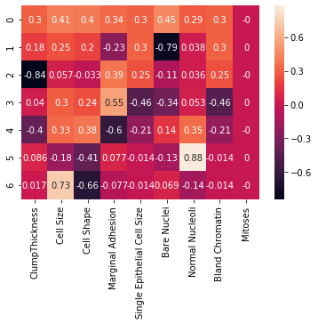

```python
sns.heatmap(pd.DataFrame(datab_pca.components_,columns=X_train.columns),annot=True)
```

# Popularity Based Recommendation System

### About Dataset

Anonymous Ratings on jokes.

1. Ratings are real values ranging from -10.00 to +10.00 (the value "99" corresponds to "null" = "not rated").
2. One row per user
3. The first column gives the number of jokes rated by that user. The next 100 columns give the ratings for jokes 01 - 100.

# Q11 Read the dataset(jokes.csv)

```python
df_jokes=pd.read_csv('jokes.csv')
df_jokes.head()
```

|  | NumJokes | Joke1 | Joke2 | Joke3 | Joke4 | Joke5 | Joke6 | Joke7 | Joke8 | Joke9 | ... | Joke91 | Joke92 | Joke93 | Joke94 | Joke95 | Joke96 | Joke97 | Joke98 | Joke99 | Joke100 |
| --- | --- | --- | --- | --- | --- | --- | --- | --- | --- | --- | --- | --- | --- | --- | --- | --- | --- | --- | --- | --- | --- |
| 0 | 74 | -7.82 | 8.79 | -9.66 | -8.16 | -7.52 | -8.50 | -9.85 | 4.17 | -8.98 | ... | 2.82 | 99.00 | 99.00 | 99.00 | 99.00 | 99.00 | -5.63 | 99.00 | 99.00 | 99.00 |
| 1 | 100 | 4.08 | -0.29 | 6.36 | 4.37 | -2.38 | -9.66 | -0.73 | -5.34 | 8.88 | ... | 2.82 | -4.95 | -0.29 | 7.86 | -0.19 | -2.14 | 3.06 | 0.34 | -4.32 | 1.07 |
| 2 | 49 | 99.00 | 99.00 | 99.00 | 99.00 | 9.03 | 9.27 | 9.03 | 9.27 | 99.00 | ... | 99.00 | 99.00 | 99.00 | 9.08 | 99.00 | 99.00 | 99.00 | 99.00 | 99.00 | 99.00 |
| 3 | 48 | 99.00 | 8.35 | 99.00 | 99.00 | 1.80 | 8.16 | -2.82 | 6.21 | 99.00 | ... | 99.00 | 99.00 | 99.00 | 0.53 | 99.00 | 99.00 | 99.00 | 99.00 | 99.00 | 99.00 |
| 4 | 91 | 8.50 | 4.61 | -4.17 | -5.39 | 1.36 | 1.60 | 7.04 | 4.61 | -0.44 | ... | 5.19 | 5.58 | 4.27 | 5.19 | 5.73 | 1.55 | 3.11 | 6.55 | 1.80 | 1.60 |

5 rows × 101 columns

```python
df_jokes.columns
```

```
Index(['NumJokes', 'Joke1', 'Joke2', 'Joke3', 'Joke4', 'Joke5', 'Joke6',
       'Joke7', 'Joke8', 'Joke9',
       ...
       'Joke91', 'Joke92', 'Joke93', 'Joke94', 'Joke95', 'Joke96', 'Joke97',
       'Joke98', 'Joke99', 'Joke100'],
      dtype='object', length=101)
```

# Q12 Consider `ratings` named dataframe with only first 200 rows and all columns from 1(first column is 0) of dataset

```python
ratings=df_jokes.drop(['NumJokes'],axis=1)
ratings.shape
```

```
(24983, 100)
```

```python
ratings=ratings.drop(ratings.index[200:])
```

# Q13 In the dataset, the null ratings are given as 99.00, so replace all 99.00s with 0

Hint: You can use `ratings.replace(<the given value>, <new value you wanted to change with>)`

```python
ratings.replace(99,0,inplace=True)
```

```python
ratings.head()
```

|  | Joke1 | Joke2 | Joke3 | Joke4 | Joke5 | Joke6 | Joke7 | Joke8 | Joke9 | Joke10 | ... | Joke91 | Joke92 | Joke93 | Joke94 | Joke95 | Joke96 | Joke97 | Joke98 | Joke99 | Joke100 |
| --- | --- | --- | --- | --- | --- | --- | --- | --- | --- | --- | --- | --- | --- | --- | --- | --- | --- | --- | --- | --- | --- |
| 0 | -7.82 | 8.79 | -9.66 | -8.16 | -7.52 | -8.50 | -9.85 | 4.17 | -8.98 | -4.76 | ... | 2.82 | 0.00 | 0.00 | 0.00 | 0.00 | 0.00 | -5.63 | 0.00 | 0.00 | 0.00 |
| 1 | 4.08 | -0.29 | 6.36 | 4.37 | -2.38 | -9.66 | -0.73 | -5.34 | 8.88 | 9.22 | ... | 2.82 | -4.95 | -0.29 | 7.86 | -0.19 | -2.14 | 3.06 | 0.34 | -4.32 | 1.07 |
| 2 | 0.00 | 0.00 | 0.00 | 0.00 | 9.03 | 9.27 | 9.03 | 9.27 | 0.00 | 0.00 | ... | 0.00 | 0.00 | 0.00 | 9.08 | 0.00 | 0.00 | 0.00 | 0.00 | 0.00 | 0.00 |
| 3 | 0.00 | 8.35 | 0.00 | 0.00 | 1.80 | 8.16 | -2.82 | 6.21 | 0.00 | 1.84 | ... | 0.00 | 0.00 | 0.00 | 0.53 | 0.00 | 0.00 | 0.00 | 0.00 | 0.00 | 0.00 |
| 4 | 8.50 | 4.61 | -4.17 | -5.39 | 1.36 | 1.60 | 7.04 | 4.61 | -0.44 | 5.73 | ... | 5.19 | 5.58 | 4.27 | 5.19 | 5.73 | 1.55 | 3.11 | 6.55 | 1.80 | 1.60 |

5 rows × 100 columns

### Popularity based recommendation system

# Q14 Find the mean for each column in `ratings_diff` i.e, for each joke

Consider all the mean ratings and find the jokes with highest mean value and display the top 10 joke IDs.

```python
ratings_diff=ratings.mean()
```

```python
ratings_diff.sort_values(ascending=False).head(10)
```

```
Joke50    4.05540
Joke36    3.61150
Joke53    3.57150
Joke35    3.22315
Joke29    3.18995
Joke27    3.05240
Joke62    2.86185
Joke49    2.85000
Joke32    2.77955
Joke31    2.65710
dtype: float64
```